# 📊 Forecasting Migration Flows — **Notebook 02: Exploratory Data Analysis (EDA)**

| **Author** | Golib Sanaev |
| --- | --- |
| **Project** | Forecasting Migration Flows with Machine Learning |
| **Created** | 2025-09-23 |
| **Last Updated** | 2025-10-14 |

### 🎯 Purpose

This notebook performs **exploratory data analysis (EDA)** on the cleaned datasets produced in **Notebook 01: Data Preparation and Cleaning**.

The goal is to uncover key **trends**, **relationships**, and **potential predictors** of international migration flows.

Key analytical steps include:

- Visualizing indicator distributions and time coverage
- Analyzing net migration trends across countries and aggregates
- Exploring correlations between migration and key economic/demographic indicators
- Detecting outliers, data clusters, and country-level case studies

## 📑 Table of Contents

- ⚙️ 1. Setup and Load Clean Data
- 🔍 2. Quick Sanity Checks
- 📈 3. Indicator Distributions
- 🌍 4. Focus on Net Migration (per 1,000 People)
  - 📊 4.1 Distribution: Original vs Capped
  - ⚠️ 4.2 Crisis Flag (for Modeling and EDA)
  - 🚨 4.3 Outlier Countries by Income Group
- 🌐 5. Global Trend Over Time
- 📉 6. Country-Level Variation
- 🚀 7. Top Migration Inflows and Outflows (Average 1990–2023)
- 🌎 8. Global vs Regional Migration Trends
- 🔗 9. Correlation and Feature Relationships
- 🗺️ 10. Country-Level Trends
- 🧩 11. Key Insights Summary

## ⚙️ 1. Setup and Load Clean Data

**Purpose:**  
Load the cleaned **country-level** and **aggregate-level** datasets, configure plotting styles, and verify the presence of key derived fields (e.g., *migration per 1,000 population*).

**Note:**  
The cleaned dataset `countries_clean.csv` is updated in this notebook to include derived variables such as `net_migration_per_1000` and other EDA refinements.  
The original `net_migration` column is dropped to avoid confusion.  
This file serves as the canonical clean dataset for all downstream analyses.

⬆️ Back to top

```python
# === Imports and Setup ===

# --- Library Imports ---
import pandas as pd
import numpy as np
from pathlib import Path
import matplotlib.pyplot as plt
import seaborn as sns
import math

# --- Safe, future-proof version ---
import warnings
warnings.filterwarnings(
    "ignore",
    message="DataFrameGroupBy.apply operated on the grouping columns",
    category=FutureWarning,
)

# --- Visualization Style ---
sns.set_theme(style="whitegrid")
plt.rcParams.update({
    "figure.facecolor": "white",
    "axes.facecolor": "white",
    "figure.dpi": 120,
})

# --- Paths and Data Loading ---
DATA_DIR = Path("../data/processed")
df_country = pd.read_csv(DATA_DIR / "countries_clean.csv")
df_agg = pd.read_csv(DATA_DIR / "aggregates_clean.csv")

print(f"[INFO] Countries dataset shape:  {df_country.shape}")
print(f"[INFO] Aggregates dataset shape: {df_agg.shape}")

# --- Derived Variable: Net Migration per 1,000 People ---
df_country["net_migration_per_1000"] = (
    df_country["net_migration"] / df_country["population"] * 1000
)
df_country = df_country.drop(columns=["net_migration"])

print("[INFO] Added 'net_migration_per_1000' and dropped 'net_migration' column.")

# --- Save Updated Countries Dataset (with per-1000 variable) ---
save_path = DATA_DIR / "countries_clean.csv"
df_country.to_csv(save_path, index=False)
print(f"[INFO] Updated 'countries_clean.csv' saved to: {save_path}")
```

```
[INFO] Countries dataset shape:  (5712, 21)
[INFO] Aggregates dataset shape: (1496, 18)
[INFO] Added 'net_migration_per_1000' and dropped 'net_migration' column.
[INFO] Updated 'countries_clean.csv' saved to: ../data/processed/countries_clean.csv
```

## 🔍 2. Quick Sanity Checks

**Purpose:**  
Verify dataset coverage (countries × years) and inspect basic missingness before proceeding with analysis.

⬆️ Back to top

```python
# === Quick Sanity Checks ===

# --- Coverage Summary ---
n_countries = df_country["Country Name"].nunique()
n_years = df_country["year"].nunique()

print(f"[INFO] Unique countries: {n_countries}")
print(f"[INFO] Years covered:     {n_years}")
print(f"[INFO] Expected rows:     {n_countries * n_years:,}")
print(f"[INFO] Actual rows:       {len(df_country):,}")

# --- Basic Missing Value Check ---
na_cols = df_country.isna().sum()
print("\n[INFO] Columns with any missing values (should be 0 except metadata, if any):")
display(na_cols[na_cols > 0])

# --- Order Income Groups for Consistent Plotting ---
if "IncomeGroup" in df_country.columns:
    order = ["Low income", "Lower middle income", "Upper middle income", "High income"]
    df_country["IncomeGroup"] = pd.Categorical(
        df_country["IncomeGroup"], categories=order, ordered=True
    )
    df_country = df_country[df_country["IncomeGroup"].notna()].copy()
    print("[INFO] Ordered 'IncomeGroup' categories and removed missing entries.")
```

```
[INFO] Unique countries: 168
[INFO] Years covered:     34
[INFO] Expected rows:     5,712
[INFO] Actual rows:       5,712

[INFO] Columns with any missing values (should be 0 except metadata, if any):
```

```
Series([], dtype: int64)
```

```
[INFO] Ordered 'IncomeGroup' categories and removed missing entries.
```

## 📈 3. Indicator Distributions

Understanding the overall data landscape helps contextualize migration patterns. Before analyzing migration directly, we first explore the **distributions of key socio-economic and demographic indicators** such as GDP, fertility, life expectancy, and population growth.

**Interpretation Tips:**

- Skewed or heavy-tailed variables (e.g., GDP per capita, population) may require log transformation during modeling.
- The shape of each distribution highlights global disparities and may reveal measurement or scale inconsistencies.
- Comparing **net migration** to other indicators clarifies whether extreme migration rates are common or exceptional.

⬆️ Back to top

```
[INFO] Plotting distributions for 16 numeric indicators.
```

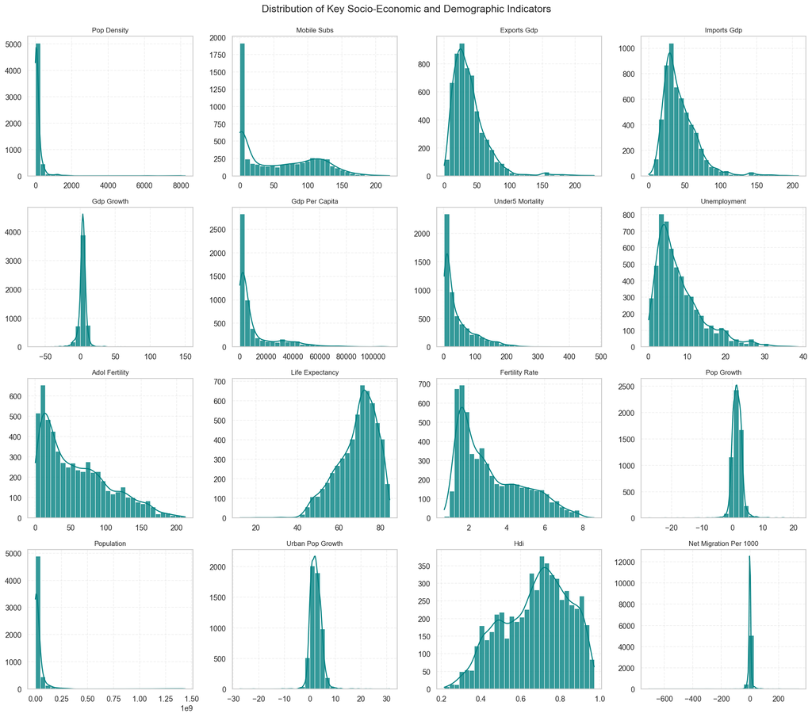

```python
# === Distribution of Key Socio-Economic and Demographic Indicators ===

# --- Define Numeric Columns of Interest ---
numeric_cols = [
    "pop_density", "mobile_subs", "exports_gdp", "imports_gdp",
    "gdp_growth", "gdp_per_capita", "under5_mortality", "unemployment",
    "adol_fertility", "life_expectancy", "fertility_rate", "pop_growth",
    "population", "urban_pop_growth", "hdi", "net_migration_per_1000",
]

# --- Filter to Columns Present in Data ---
numeric_cols = [c for c in numeric_cols if c in df_country.columns]
print(f"[INFO] Plotting distributions for {len(numeric_cols)} numeric indicators.")

# --- Setup Plot Grid ---
n_cols = 4
n_rows = math.ceil(len(numeric_cols) / n_cols)

plt.figure(figsize=(n_cols * 4.2, n_rows * 3.6))

# --- Plot Histograms ---
for i, col in enumerate(numeric_cols, 1):
    plt.subplot(n_rows, n_cols, i)
    sns.histplot(
        df_country[col],
        kde=True,
        bins=30,
        color="teal",
        alpha=0.8,
    )
    plt.title(col.replace("_", " ").title(), fontsize=10)
    plt.xlabel("")
    plt.ylabel("")
    plt.grid(alpha=0.3, linestyle="--")

plt.tight_layout()
plt.suptitle(
    "Distribution of Key Socio-Economic and Demographic Indicators",
    fontsize=15,
    y=1.02,
)
plt.show()
```

## 🌍 4. Focus on Net Migration (per 1,000 People)

**Interpretation Tip:**  
The distribution is concentrated around zero, with a small number of countries exhibiting extreme inflows (e.g., Gulf states) or outflows (e.g., conflict-affected nations).

⬆️ Back to top

### 📊 4.1 Distribution: Original vs Capped

**Purpose:**  
Compare the full distribution to a capped version for clearer visualization. Values are capped at ±50 to reduce the impact of extreme crisis years while still preserving those cases in the data.

⬆️ Back to top

```
[INFO] Created capped variable 'net_migration_per_1000_capped' at ±50.
```

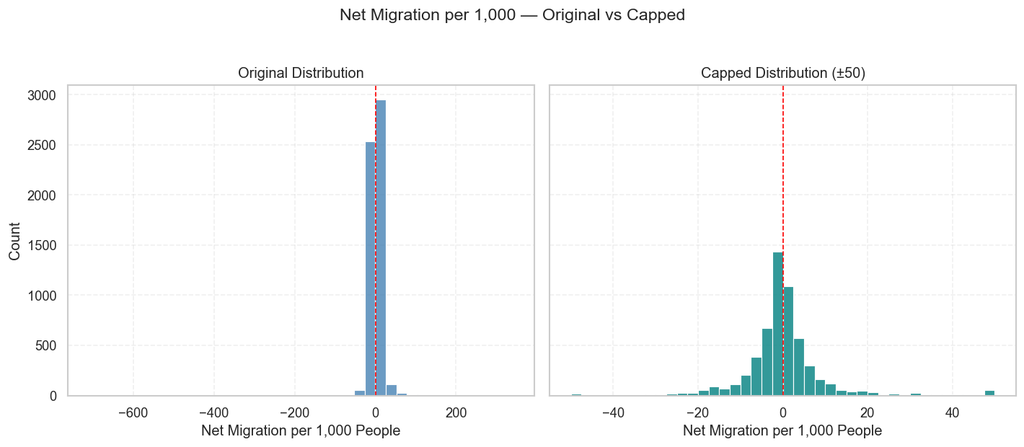

|  | Original |
| --- | --- |
| count | 5712.000000 |
| mean | 0.008882 |
| std | 17.733863 |
| min | -709.898215 |
| 1% | -29.145429 |
| 5% | -14.879145 |
| 50% | -0.294753 |
| 95% | 14.405584 |
| 99% | 44.691864 |
| max | 340.852702 |

|  | Capped ±50 |
| --- | --- |
| count | 5712.000000 |
| mean | 0.012129 |
| std | 10.346746 |
| min | -50.000000 |
| 1% | -29.145429 |
| 5% | -14.879145 |
| 50% | -0.294753 |
| 95% | 14.405584 |
| 99% | 44.691864 |
| max | 50.000000 |

```python
# === Net Migration Distribution: Original vs Capped ===

# --- Create Capped Version for Visualization ---
CAP = 50
if "net_migration_per_1000_capped" not in df_country.columns:
    df_country["net_migration_per_1000_capped"] = df_country["net_migration_per_1000"].clip(-CAP, CAP)
    print(f"[INFO] Created capped variable 'net_migration_per_1000_capped' at ±{CAP}.")
else:
    print("[INFO] Using existing capped variable 'net_migration_per_1000_capped'.")

# --- Setup Figure ---
fig, axes = plt.subplots(1, 2, figsize=(12, 5), sharey=True)

# --- Original Distribution ---
sns.histplot(df_country["net_migration_per_1000"], bins=40, ax=axes[0], color="steelblue", alpha=0.8)
axes[0].axvline(0, color="red", linestyle="--", lw=1)
axes[0].set_title("Original Distribution")

# --- Capped Distribution ---
sns.histplot(df_country["net_migration_per_1000_capped"], bins=40, ax=axes[1], color="teal", alpha=0.8)
axes[1].axvline(0, color="red", linestyle="--", lw=1)
axes[1].set_title(f"Capped Distribution (±{CAP})")

# --- Common Axes Formatting ---
for ax in axes:
    ax.set_xlabel("Net Migration per 1,000 People")
    ax.set_ylabel("Count")
    ax.grid(alpha=0.3, linestyle="--")

# --- Force Same Y-Scale for Fair Comparison ---
ymax = max(ax.get_ylim()[1] for ax in axes)
for ax in axes:
    ax.set_ylim(0, ymax)

plt.suptitle("Net Migration per 1,000 — Original vs Capped", fontsize=14, y=1.03)
plt.tight_layout()
plt.show()

# --- Distribution Summary Statistics ---
display(
    df_country["net_migration_per_1000"]
        .describe(percentiles=[0.01, 0.05, 0.5, 0.95, 0.99])
        .to_frame("Original"),
    df_country["net_migration_per_1000_capped"]
        .describe(percentiles=[0.01, 0.05, 0.5, 0.95, 0.99])
        .to_frame(f"Capped ±{CAP}"),
)
```

### ⚠️ 4.2 Crisis Flag (for Modeling and EDA)

**Why create `is_crisis`?**  
Some countries experience *extreme spikes or drops* in migration due to wars, economic collapse, or humanitarian crises. Such outliers can distort model training if treated as ordinary observations.

- A year is marked as a **crisis** if  
  **|net_migration_per_1000| > 50 → `is_crisis = 1`**
- These rows are **kept** (not removed) to preserve temporal continuity.
- The **capped** version is used for plots, while **`is_crisis`** serves as a modeling control variable.

⬆️ Back to top

```python
# === Create Crisis Flag ===

# --- Define Binary Crisis Indicator ---
df_country["is_crisis"] = (df_country["net_migration_per_1000"].abs() > CAP).astype(int)
print(f"[INFO] Created binary crisis flag 'is_crisis' (threshold: ±{CAP}).")

# --- Summarize Crisis Counts by Income Group ---
if "IncomeGroup" in df_country.columns:
    crisis_counts = (
        df_country.groupby("IncomeGroup", observed=True)["is_crisis"]
        .sum()
        .sort_values(ascending=False)
    )
    print("\n[INFO] Crisis-year counts by income group:")
    display(crisis_counts)
```

```
[INFO] Created binary crisis flag 'is_crisis' (threshold: ±50).

[INFO] Crisis-year counts by income group:
```

```
IncomeGroup
High income            29
Low income             19
Lower middle income    14
Upper middle income     4
Name: is_crisis, dtype: int64
```

### 🚨 4.3 Outlier Countries by Income Group

**Purpose:**  
Identify countries driving extreme migration patterns within each income group using a **fixed threshold** of ±50 per 1,000 (`is_crisis`). The table below displays all crisis observations by income group, followed by a bar chart summarizing counts.

⬆️ Back to top

```
[INFO] Generating crisis-level migration summary by income group...
```

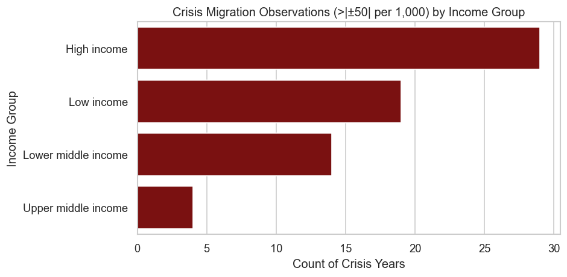

|  | Low income | Upper middle income | Lower middle income | High income |
| --- | --- | --- | --- | --- |
| 1 | Rwanda (1994, -305.9) | Ukraine (2022, -138.8) | Timor-Leste (1999, -315.0) | Kuwait (1990, -709.9) |
| 2 | Rwanda (1996, 203.9) | Bosnia and Herzegovina (1992, -103.2) | Lebanon (2013, 127.7) | Kuwait (1991, 340.9) |
| 3 | Eritrea (1991, -171.2) | Libya (2011, -88.7) | Bhutan (1992, -114.1) | Qatar (2006, 209.9) |
| 4 | Burundi (1993, -120.5) | Armenia (1992, -54.9) | Djibouti (1992, -104.2) | Qatar (2007, 203.3) |
| 5 | Syrian Arab Republic (2013, -96.1) | NaN | Djibouti (1990, 86.2) | Oman (2011, 160.1) |
| 6 | Burundi (1994, 90.4) | NaN | Jordan (2006, 78.2) | United Arab Emirates (2007, 128.4) |
| 7 | Afghanistan (1992, 90.2) | NaN | Jordan (2013, 76.3) | Qatar (2008, 116.0) |
| 8 | Somalia, Fed. Rep. (1991, -83.4) | NaN | Jordan (1990, 73.5) | Oman (2012, 91.0) |
| 9 | Rwanda (1995, 77.5) | NaN | Jordan (2014, 72.3) | Qatar (2014, 90.5) |
| 10 | Afghanistan (1993, 76.9) | NaN | Timor-Leste (2001, 60.5) | Qatar (2005, 83.6) |
| 11 | Syrian Arab Republic (2014, -71.9) | NaN | Timor-Leste (2000, 54.0) | United Arab Emirates (2008, 83.0) |
| 12 | Togo (1993, -69.2) | NaN | Cambodia (1994, 52.9) | Kuwait (2022, 80.3) |
| 13 | Eritrea (1995, 67.2) | NaN | Jordan (2015, 51.4) | United Arab Emirates (2006, 79.7) |
| 14 | South Sudan (2017, -65.4) | NaN | Cambodia (1995, 50.2) | Qatar (2009, 76.6) |
| 15 | Mozambique (1994, 62.4) | NaN | NaN | Qatar (2015, 75.7) |
| 16 | South Sudan (2016, -60.4) | NaN | NaN | Oman (2022, 71.7) |
| 17 | Sierra Leone (1991, -56.3) | NaN | NaN | Qatar (2013, 69.7) |
| 18 | Rwanda (1997, 52.9) | NaN | NaN | United Arab Emirates (1996, 69.4) |
| 19 | Afghanistan (2000, -51.0) | NaN | NaN | United Arab Emirates (1997, 65.1) |
| 20 | NaN | NaN | NaN | Bahrain (2002, 64.7) |
| 21 | NaN | NaN | NaN | United Arab Emirates (1998, 60.3) |
| 22 | NaN | NaN | NaN | Bahrain (2003, 59.6) |
| 23 | NaN | NaN | NaN | Kuwait (2011, 56.4) |
| 24 | NaN | NaN | NaN | Qatar (2010, 56.0) |
| 25 | NaN | NaN | NaN | United Arab Emirates (1999, 55.3) |
| 26 | NaN | NaN | NaN | Bahrain (2004, 55.1) |
| 27 | NaN | NaN | NaN | Bahrain (2001, 52.0) |
| 28 | NaN | NaN | NaN | Bahrain (2005, 51.4) |
| 29 | NaN | NaN | NaN | United Arab Emirates (2000, 51.1) |

```python
# === Outlier Countries by Income Group (±50 per 1,000) ===

import math

# --- Define Helper Function ---
def crisis_table_by_income(df, value_col="net_migration_per_1000", cap=50):
    """
    Generate a summary table of countries with crisis-level migration
    (|net_migration_per_1000| > cap) grouped by IncomeGroup.
    Returns both a display table and a count bar chart.
    """
    groups = df["IncomeGroup"].dropna().unique()
    result, counts = {}, {}

    # --- Identify Crisis Cases by Income Group ---
    for g in groups:
        crisis = df.loc[
            (df["IncomeGroup"] == g) & (df[value_col].abs() > cap)
        ].copy()
        if crisis.empty:
            continue

        counts[g] = len(crisis)
        result[g] = (
            crisis.assign(
                info=lambda x: (
                    x["Country Name"]
                    + " (" + x["year"].astype(str)
                    + ", " + x[value_col].round(1).astype(str)
                    + ")"
                )
            )
            .sort_values(value_col, key=lambda x: x.abs(), ascending=False)["info"]
            .reset_index(drop=True)
        )

    # --- Align Lengths Across Columns ---
    max_len = max((len(v) for v in result.values()), default=0)
    table = pd.DataFrame({k: v.reindex(range(max_len)) for k, v in result.items()})
    table.index = range(1, len(table) + 1)

    # --- Plot Crisis Counts by Income Group ---
    counts_series = pd.Series(counts).sort_values(ascending=False)
    plt.figure(figsize=(8, 4))
    sns.barplot(x=counts_series.values, y=counts_series.index, color="darkred")
    plt.title(f"Crisis Migration Observations (>|±{cap}| per 1,000) by Income Group")
    plt.xlabel("Count of Crisis Years")
    plt.ylabel("Income Group")
    plt.tight_layout()
    plt.show()

    return table


# --- Generate and Display Crisis Table ---
print("[INFO] Generating crisis-level migration summary by income group...")
crisis_table_full = crisis_table_by_income(df_country, cap=50)
display(crisis_table_full)
```

## 🌐 5. Global Trend Over Time

**Purpose:**  
Visualize the global average net migration rate per year to detect common cycles, turning points, or long-term shifts in global migration dynamics.

⬆️ Back to top

```
[INFO] Computed global average migration rates for 34 years.
```

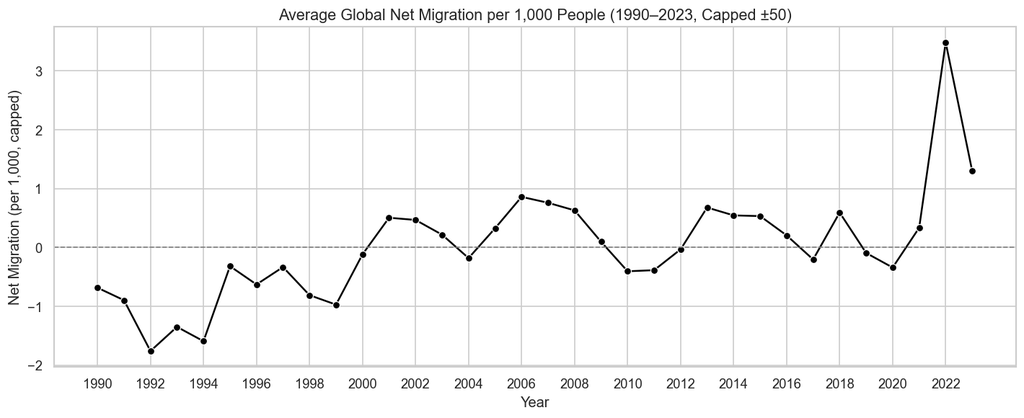

```python
# === Global Trend Over Time ===

# --- Compute Global Average (Capped) Net Migration per Year ---
global_trend = (
    df_country.groupby("year")["net_migration_per_1000_capped"]
    .mean()
    .reset_index()
)

print(f"[INFO] Computed global average migration rates for {len(global_trend)} years.")

# --- Plot Global Trend ---
plt.figure(figsize=(12, 5))
sns.lineplot(
    data=global_trend,
    x="year",
    y="net_migration_per_1000_capped",
    marker="o",
    color="black",
)

plt.title("Average Global Net Migration per 1,000 People (1990–2023, Capped ±50)", fontsize=13)
plt.xlabel("Year")
plt.ylabel("Net Migration (per 1,000, capped)")
plt.axhline(0, color="gray", linestyle="--", lw=1)

# --- Format X-Axis ---
years = sorted(df_country["year"].unique())
plt.xticks(ticks=[y for y in years if y % 2 == 0])

plt.tight_layout()
plt.show()
```

## 📉 6. Country-Level Variation

**Purpose:**  
Identify countries with the most **volatile migration histories**, measured by the standard deviation of net migration per 1,000 people across years.

⬆️ Back to top

```
[INFO] Computed migration volatility for 168 countries.
```

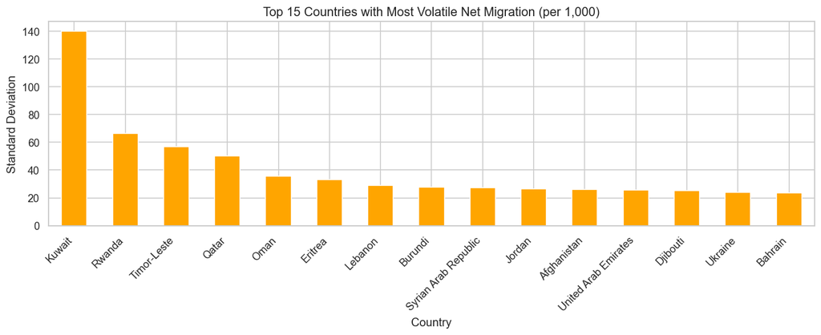

```python
# === Country-Level Migration Volatility ===

# --- Compute Standard Deviation of Net Migration per Country ---
migration_variability = (
    df_country.groupby("Country Name")["net_migration_per_1000"]
    .std()
    .sort_values(ascending=False)
)

print(f"[INFO] Computed migration volatility for {len(migration_variability)} countries.")

# --- Plot Top 15 Most Volatile Countries ---
plt.figure(figsize=(12, 5))
migration_variability.head(15).plot(kind="bar", color="orange")

plt.title("Top 15 Countries with Most Volatile Net Migration (per 1,000)", fontsize=13)
plt.ylabel("Standard Deviation")
plt.xlabel("Country")
plt.xticks(rotation=45, ha="right")

plt.tight_layout()
plt.show()
```

## 🚀 7. Top Migration Inflows and Outflows (Average 1990–2023)

**Purpose:**  
Highlight countries with the highest **average net inflows** and **outflows** of migration over the entire 1990–2023 period.

⬆️ Back to top

```
[INFO] Displaying top 10 inflow and outflow countries (1990–2023).
```

| Country Name | Average per 1,000 | Type |
| --- | --- | --- |
| Tonga | -20.43 | Outflow |
| Samoa | -17.41 | Outflow |
| Moldova | -16.12 | Outflow |
| Albania | -14.14 | Outflow |
| Georgia | -13.71 | Outflow |
| Guyana | -13.42 | Outflow |
| El Salvador | -10.87 | Outflow |
| Fiji | -10.09 | Outflow |
| Armenia | -9.85 | Outflow |
| Eswatini | -7.99 | Outflow |
| Maldives | 8.46 | Inflow |
| Cyprus | 9.73 | Inflow |
| Singapore | 13.16 | Inflow |
| Luxembourg | 13.40 | Inflow |
| Saudi Arabia | 13.60 | Inflow |
| Equatorial Guinea | 14.30 | Inflow |
| Kuwait | 16.02 | Inflow |
| Bahrain | 17.56 | Inflow |
| Qatar | 29.20 | Inflow |
| United Arab Emirates | 33.99 | Inflow |

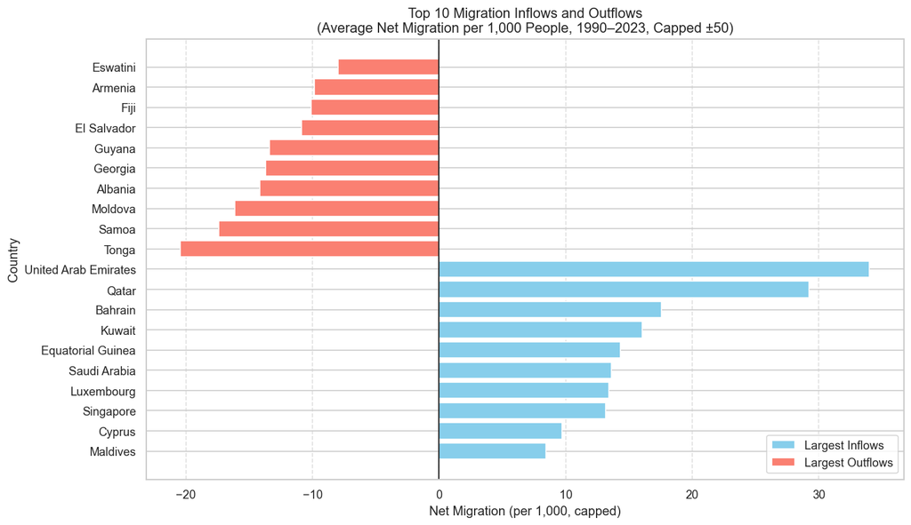

```python
# === Top Migration Inflows and Outflows (Average 1990–2023) ===

# --- Compute Average Net Migration (Capped) per Country ---
avg_migration = (
    df_country.groupby("Country Name")["net_migration_per_1000_capped"]
    .mean()
    .sort_values()
)

top_inflows = avg_migration.tail(10)
top_outflows = avg_migration.head(10)

# --- Combine and Display Summary Table ---
top_summary = pd.concat([
    top_outflows.rename("Average per 1,000").to_frame().assign(Type="Outflow"),
    top_inflows.rename("Average per 1,000").to_frame().assign(Type="Inflow"),
])

print("[INFO] Displaying top 10 inflow and outflow countries (1990–2023).")
display(top_summary.round(2))

# --- Plot Top Inflows and Outflows ---
plt.figure(figsize=(12, 7))
plt.barh(top_inflows.index, top_inflows, color="skyblue", label="Largest Inflows")
plt.barh(top_outflows.index, top_outflows, color="salmon", label="Largest Outflows")
plt.axvline(0, color="black", linewidth=1)

plt.title(
    "Top 10 Migration Inflows and Outflows\n"
    "(Average Net Migration per 1,000 People, 1990–2023, Capped ±50)",
    fontsize=13,
)
plt.xlabel("Net Migration (per 1,000, capped)")
plt.ylabel("Country")
plt.legend(loc="lower right", frameon=True)
plt.grid(axis="x", linestyle="--", alpha=0.6)

plt.tight_layout()
plt.show()
```

## 🌎 8. Global vs Regional Migration Trends

**Purpose:**  
Compare the **global average** migration trend against selected **regions** and **income groups** derived from `df_country`.

⬆️ Back to top

```
[INFO] Computed global, regional, and income-group migration trends.
```

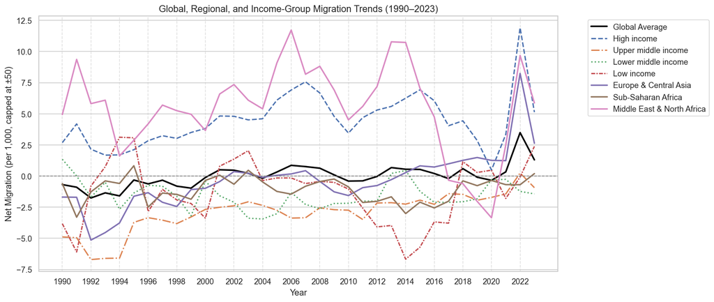

```python
# === Global vs Regional and Income-Group Migration Trends ===

# --- Ensure Capped Migration Variable Exists ---
if "net_migration_per_1000_capped" not in df_country.columns:
    df_country["net_migration_per_1000_capped"] = df_country["net_migration_per_1000"].clip(-50, 50)
    print("[INFO] Created capped variable 'net_migration_per_1000_capped' (±50).")

# --- Compute Global Average ---
global_trend = (
    df_country.groupby("year")["net_migration_per_1000_capped"]
    .mean()
    .reset_index()
)

# --- Compute Regional Averages ---
region_trends = (
    df_country.groupby(["Region", "year"], observed=True)["net_migration_per_1000_capped"]
    .mean()
    .reset_index()
)

# --- Compute Income-Group Averages ---
income_trends = (
    df_country.groupby(["IncomeGroup", "year"], observed=True)["net_migration_per_1000_capped"]
    .mean()
    .reset_index()
)

print("[INFO] Computed global, regional, and income-group migration trends.")

# --- Plot Global, Regional, and Income-Group Trends ---
plt.figure(figsize=(14, 6))

# Global Average (bold black line)
sns.lineplot(
    data=global_trend,
    x="year",
    y="net_migration_per_1000_capped",
    color="black",
    linewidth=2.2,
    label="Global Average",
)

# Income Groups (dashed styles)
for group, style in zip(
    ["High income", "Upper middle income", "Lower middle income", "Low income"],
    ["--", "-.", ":", (0, (3, 1, 1, 1))],
):
    sub = income_trends[income_trends["IncomeGroup"] == group]
    sns.lineplot(
        data=sub,
        x="year",
        y="net_migration_per_1000_capped",
        linestyle=style,
        linewidth=1.8,
        label=group,
    )

# Key Regions (solid lines)
for region in ["Europe & Central Asia", "Sub-Saharan Africa", "Middle East & North Africa"]:
    sub = region_trends[region_trends["Region"] == region]
    sns.lineplot(
        data=sub,
        x="year",
        y="net_migration_per_1000_capped",
        linewidth=2.0,
        label=region,
    )

plt.axhline(0, color="gray", linestyle="--", lw=1)
plt.title("Global, Regional, and Income-Group Migration Trends (1990–2023)", fontsize=13)
plt.xlabel("Year")
plt.ylabel("Net Migration (per 1,000, capped at ±50)")
plt.legend(bbox_to_anchor=(1.05, 1), loc="upper left", frameon=True)
plt.grid(axis="x", linestyle="--", alpha=0.6)
plt.xticks(range(1990, 2024, 2))

plt.tight_layout()
plt.show()
```

## 🔗 9. Correlation and Feature Relationships

**Purpose:**  
Explore how **migration intensity** relates to key **demographic**, **economic**, and **social** indicators. We use the capped version of migration (`net_migration_per_1000_capped`) to focus on *structural relationships* rather than one-off crisis spikes that could distort correlations.

This analysis helps uncover the **underlying drivers** of migration patterns — such as fertility decline, urbanization, and income growth — without overemphasizing short-lived shocks.

⬆️ Back to top

```
[INFO] Using 16 numeric variables for correlation analysis.
[INFO] Heatmap saved to: ../docs/correlation_heatmap_country_level.png
```

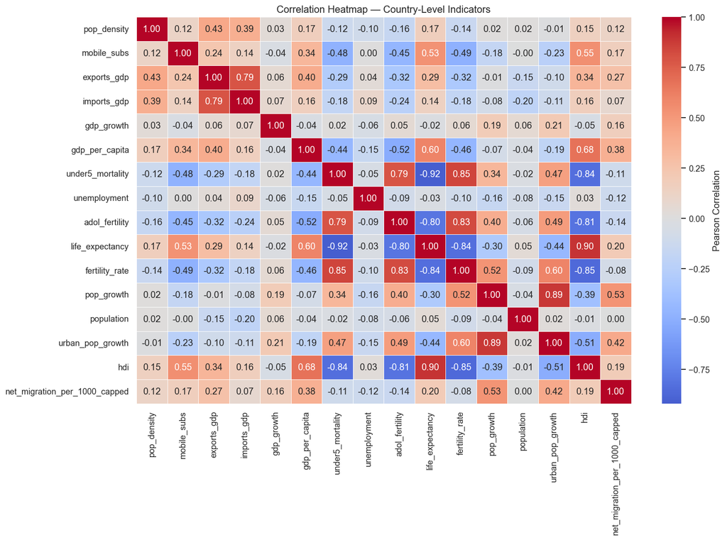

```
[INFO] Top correlated indicators with net migration (capped):
```

|  | Correlation with Net Migration (per 1,000, capped) |
| --- | --- |
| pop_growth | 0.525 |
| urban_pop_growth | 0.417 |
| gdp_per_capita | 0.378 |
| exports_gdp | 0.268 |
| life_expectancy | 0.202 |
| hdi | 0.194 |
| mobile_subs | 0.171 |
| gdp_growth | 0.161 |
| pop_density | 0.117 |
| imports_gdp | 0.072 |
| population | 0.001 |
| fertility_rate | -0.078 |
| under5_mortality | -0.109 |
| unemployment | -0.125 |
| adol_fertility | -0.143 |

```python
# === Correlation and Feature Relationships ===

# --- Select Available Numeric Columns ---
numeric_cols = [
    "pop_density", "mobile_subs", "exports_gdp", "imports_gdp",
    "gdp_growth", "gdp_per_capita", "under5_mortality", "unemployment",
    "adol_fertility", "life_expectancy", "fertility_rate", "pop_growth",
    "population", "urban_pop_growth", "hdi", "net_migration_per_1000_capped"
]

corr_cols = [c for c in numeric_cols if c in df_country.columns]
print(f"[INFO] Using {len(corr_cols)} numeric variables for correlation analysis.")

# --- Compute Correlation Matrix ---
corr = df_country[corr_cols].corr()

# --- Plot Correlation Heatmap ---
plt.figure(figsize=(14, 10))
sns.heatmap(
    corr,
    cmap="coolwarm",
    center=0,
    annot=True,
    fmt=".2f",
    cbar_kws={"label": "Pearson Correlation"},
    linewidths=0.5,
)

plt.title("Correlation Heatmap — Country-Level Indicators", fontsize=13)
plt.tight_layout()

# --- Save Heatmap as Image for Notebook 03 ---
output_path = Path("../docs")
output_path.mkdir(parents=True, exist_ok=True)
save_path = output_path / "correlation_heatmap_country_level.png"
plt.savefig(save_path, dpi=300, bbox_inches="tight")
print(f"[INFO] Heatmap saved to: {save_path}")

plt.show()

# --- Identify Top Correlated Indicators with Migration ---
corr_table = (
    corr["net_migration_per_1000_capped"]
    .drop("net_migration_per_1000_capped")
    .sort_values(ascending=False)
    .to_frame("Correlation with Net Migration (per 1,000, capped)")
    .round(3)
)

print("[INFO] Top correlated indicators with net migration (capped):")
display(corr_table)
```

### 🧭 Feature Correlation Insights and Next Steps

The correlation analysis revealed clusters of **highly collinear indicators** — notably `exports_gdp` ↔ `imports_gdp`, and `urban_pop_growth` ↔ `pop_growth`.  
To improve interpretability and minimize redundancy, the following refinements will be applied in **Notebook 03: Feature Engineering and Modeling**:

- **Variable selection:** retain only one representative variable from strongly correlated pairs.
- **Derived indicators:** create balanced or stability measures, such as
  - `trade_openness_ratio` = exports / imports
  - `urbanization_rate_stable` = urban population growth / total population growth
- **Temporal dynamics:** include lagged variables (e.g., `is_crisis_lag1`) to capture short-term persistence in migration shocks.
- **Interaction effects:** model economic–demographic heterogeneity through terms like
  - `gdp_growth_x_<income_group>`
  - `pop_growth_x_<income_group>`

These engineered variables provide more interpretable, non-redundant features for downstream forecasting models.

## 🗺️ 10. Country-Level Trends

**Purpose:**  
Visualize migration trends across selected countries representing different migration contexts:

- **Conflict-driven outflows:** Ukraine, Syrian Arab Republic, Sudan, Afghanistan
- **Transit / mixed economies:** Türkiye, Cyprus
- **Destination economies:** United Arab Emirates, Qatar, Germany

⬆️ Back to top

```
[INFO] Plotting migration trends for 9 representative countries...
```

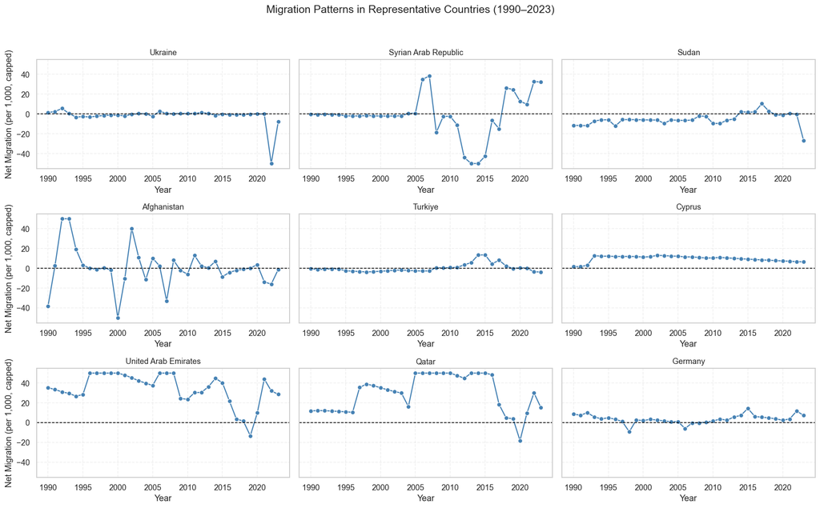

```python
# === Country-Level Migration Trends ===

# --- Define Representative Countries ---
countries_show = [
    "Ukraine", "Syrian Arab Republic", "Sudan", "Afghanistan",
    "Turkiye", "Cyprus", "United Arab Emirates", "Qatar", "Germany"
]

print(f"[INFO] Plotting migration trends for {len(countries_show)} representative countries...")

# --- Create Multi-Panel Figure ---
fig, axes = plt.subplots(3, 3, figsize=(16, 10), sharey=True)
axes = axes.flatten()

for i, country in enumerate(countries_show):
    sub = df_country[df_country["Country Name"] == country]
    if not sub.empty:
        sns.lineplot(
            ax=axes[i],
            data=sub,
            x="year",
            y="net_migration_per_1000_capped",
            marker="o",
            color="steelblue",
        )
        axes[i].axhline(0, color="black", linestyle="--", lw=1)
        axes[i].set_title(country, fontsize=11)
        axes[i].set_xlabel("Year")
        axes[i].set_ylabel("Net Migration (per 1,000, capped)")
        axes[i].grid(alpha=0.3, linestyle="--")
    else:
        axes[i].set_visible(False)

plt.suptitle("Migration Patterns in Representative Countries (1990–2023)", fontsize=15, y=0.98)
plt.tight_layout(rect=[0, 0, 1, 0.95])
plt.show()
```

The dataset is now fully prepared for **feature engineering and predictive modeling** in **Notebook 03: Feature Engineering and Modeling**.

⬆️ Back to top